# Introduction

Baseball is the best sport out there. There are lot of players who get a chance to play in the major league right after the highschool . But there are players who consider joining the college after the highschool. Do they have to be careful in picking their college ?. Getting into good college have any positive impact in their baseballcareer ?.  
To answer this questions i am going to split the players into 4 groups

Players from the top colleges

players from the colleges other than the top colleges

players who didn't attend the college

players who attend the college

To measure how successful their career is i use two attributes salary and awards. why salary and awards? salary: It varies from player to player. Based on thier performance their salary is decided. If the player performs well in the matches he will get a good salary.

salary of the baseball is decide using the salary arbitaration process and using the free agency.

**Salary arbitaration process :** Baseball's arbitration process is based on the "last best offer" principle. Under this system, the parties bargain to impass on the topic of the salary. Once it is determined that continued negotiations would be fruitless, both management and player submit one proposed salary figure to the arbitrator. The arbitarator then holds hearings, alloting one and one half for each side to present their evidence. The arbitrator must choose one figure or the other, either the player's or management's and award the player that salary for the next season. The creteria on which the arbitarator bases the decision are as follows:

The quality of the player's contribution to the club during the past season

length and the consistence of the player's career performance

The player's past compensation

comparative baseball salaries

Awards : Awards are for the players who performed exceptionally well.  
My aim here is to compare the salary and awards of the 4 groups to see the college education have any impact on the career.

# Importing

```python
#importing data analysis and wrangling packages
import numpy as np
import pandas as pd
#importing visualization
import matplotlib.pyplot as plt
%matplotlib inline
```

## Acquire data

For the analysis i have to first get the colleges and see what are the good colleges. And split the players based on their colleges. Then have to find the salary of the players and awards they receive. For this i import the college, school , awards and the salary information.

```python
college = pd.read_csv('CollegePlaying.csv') #returns dataframe containing college playing data
school = pd.read_csv('Schools.csv') #returns dataframe containing schools data
salary = pd.read_csv('Salaries.csv') # return dataframe containing salaries data
awards = pd.read_csv('AwardsPlayers.csv') #return dataframe containing awards of the players
```

# Understanding Data

#### What are the features available in the dataset?

```python
print(college.columns.values)
print (school.columns.values)
```

```
['playerID' 'schoolID' 'yearID']
['schoolID' 'name_full' 'city' 'state' 'country']
```

###### check whether this data containing any missing values?

```python
college.info()
```

```
<class 'pandas.core.frame.DataFrame'>
RangeIndex: 17350 entries, 0 to 17349
Data columns (total 3 columns):
playerID    17350 non-null object
schoolID    17350 non-null object
yearID      17350 non-null int64
dtypes: int64(1), object(2)
memory usage: 406.7+ KB
```

```python
school.info()
```

```
<class 'pandas.core.frame.DataFrame'>
RangeIndex: 1207 entries, 0 to 1206
Data columns (total 5 columns):
schoolID     1207 non-null object
name_full    1207 non-null object
city         1207 non-null object
state        1207 non-null object
country      1207 non-null object
dtypes: object(5)
memory usage: 47.2+ KB
```

All the entries in the columns are equal so both of this dataframe don't have any missing values

### Combining the dataframe

Here i am going to merge school and college dataframe so i can know the player's college name instead of player's college ID.

```python
college_details = pd.merge(school[['schoolID','name_full']],college, on ='schoolID',how = 'right')
```

Here I opt for right join because i want all the players who have studied in the college to be present in the dataframe.

```python
college_details.info()
```

```
<class 'pandas.core.frame.DataFrame'>
Int64Index: 17350 entries, 0 to 17349
Data columns (total 4 columns):
schoolID     17350 non-null object
name_full    17340 non-null object
playerID     17350 non-null object
yearID       17350 non-null int64
dtypes: int64(1), object(3)
memory usage: 677.7+ KB
```

Here in the **name_full** column 10 values are missing from the total values. By this we can say that some school ID is not present in the school dataframe. To check this i do the following

```python
college[~college['schoolID'].isin(school['schoolID'])]
```

|  | playerID | schoolID | yearID |
| --- | --- | --- | --- |
| 5170 | frascjo01 | ctpostu | 1989 |
| 5171 | frascjo01 | ctpostu | 1990 |
| 5172 | frascjo01 | ctpostu | 1991 |
| 5466 | gattiev01 | txutper | 2010 |
| 10707 | mooredo01 | txrange | 1973 |
| 13767 | scheiri01 | ctpostu | 1962 |
| 13768 | scheiri01 | ctpostu | 1963 |
| 13769 | scheiri01 | ctpostu | 1964 |
| 17073 | woodsdi01 | caallia | 1964 |
| 17074 | woodsdi01 | caallia | 1965 |

These school ID are not present in the school Dataframe. As there is no way to know the full name for these schoolID i replace the **Nan** values in the **name_full** column to **unknown university**

```python
college_details.fillna('unknown university',inplace = True)
college_details.info()
```

```
<class 'pandas.core.frame.DataFrame'>
Int64Index: 17350 entries, 0 to 17349
Data columns (total 4 columns):
schoolID     17350 non-null object
name_full    17350 non-null object
playerID     17350 non-null object
yearID       17350 non-null int64
dtypes: int64(1), object(3)
memory usage: 677.7+ KB
```

Now there is no **NaN** values in the college_details dataframe.

```python
college_details.head()
```

|  | schoolID | name_full | playerID | yearID |
| --- | --- | --- | --- | --- |
| 0 | akron | University of Akron | birkbmi01 | 1980 |
| 1 | akron | University of Akron | birkbmi01 | 1981 |
| 2 | akron | University of Akron | birkbmi01 | 1982 |
| 3 | akron | University of Akron | birkbmi01 | 1983 |
| 4 | akron | University of Akron | dilauja01 | 1962 |

Now i want to know how many players are from each college.To do this i can use group by the college name to count the player ID. But from what i saw from the above that player id is not unique. Removing the duplicates make the playerID unique.

```python
college_details.drop_duplicates('playerID', keep = 'last',inplace =True)
college_details['playerID'].is_unique
```

```
True
```

By the information available in the college and the school dataframe , i am going to group the players based on the college and see how many players are from each college.

```python
college_ranking = college_details.groupby('name_full', as_index = False)['playerID'].count()
college_ranking.rename(columns = {'playerID':'number_of_players' }, inplace= True)
```

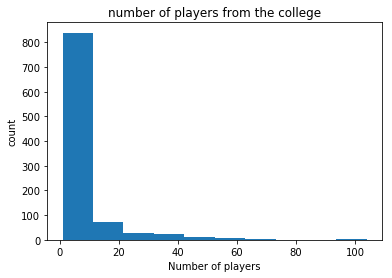

```python
plt.xlabel('Number of players')
plt.ylabel('count')
plt.title('number of players from the college')
plt.hist(college_ranking['number_of_players'],bins = 10)
```

Most of the colleges have produced less than 20 baseball students. That can due to anything like poor coaching , team cooperation. There are also some colleges that have more than 100 baseball players as their alumni . It can be also due to variety of factors. As we don't know anything about the baseballcoaching in the universities and facilities available there we can't simply tell colleges in 60-100 bins are good colleges for baseball.As there is no way to which college are good I am going to split the players in the colleges with more 40 alumini baseball players into one and the remaining into the one group and see is there any difference in their career. To prove there is difference between the college , i am going to have one group full of players who have attended college.And also going to analysis the career of the player who don'have the college education against those who have attended the college.This will give the clear picture of whether the college education have any impact on the baseball career.

```python
college_players = college_details.merge(college_ranking, on= 'name_full')
college_players.info()
```

```
<class 'pandas.core.frame.DataFrame'>
Int64Index: 6575 entries, 0 to 6574
Data columns (total 5 columns):
schoolID             6575 non-null object
name_full            6575 non-null object
playerID             6575 non-null object
yearID               6575 non-null int64
number_of_players    6575 non-null int64
dtypes: int64(2), object(3)
memory usage: 308.2+ KB
```

```python
players_from_top_colleges = college_players[college_players['number_of_players'] >= 40]
players_from_top_colleges.info()
```

```
<class 'pandas.core.frame.DataFrame'>
Int64Index: 1658 entries, 4 to 5973
Data columns (total 5 columns):
schoolID             1658 non-null object
name_full            1658 non-null object
playerID             1658 non-null object
yearID               1658 non-null int64
number_of_players    1658 non-null int64
dtypes: int64(2), object(3)
memory usage: 77.7+ KB
```

```python
players_from_other_colleges = college_players[college_players['number_of_players'] < 40]
players_from_other_colleges.info()
```

```
<class 'pandas.core.frame.DataFrame'>
Int64Index: 4917 entries, 0 to 6574
Data columns (total 5 columns):
schoolID             4917 non-null object
name_full            4917 non-null object
playerID             4917 non-null object
yearID               4917 non-null int64
number_of_players    4917 non-null int64
dtypes: int64(2), object(3)
memory usage: 230.5+ KB
```

Here, I have split the college_players into two group based on the baseball alumni from each college.

player performance can be measured in number of ways . Their career depands on their performace in the game. One best way to judge they are having a successfull career in the field is by their salary and the number of awards of they got. The best players will get the high salary by the team owners and they are awarded based on thier performance. So salary and awards are the best way to measure how good their career is.

```python
total_awards_per_player = awards.groupby('playerID',as_index = False)['awardID'].count()
total_awards_per_player.info()
```

```
<class 'pandas.core.frame.DataFrame'>
Int64Index: 1343 entries, 0 to 1342
Data columns (total 2 columns):
playerID    1343 non-null object
awardID     1343 non-null int64
dtypes: int64(1), object(1)
memory usage: 31.5+ KB
```

```python
totalsalary_of_each_players = salary.groupby(['playerID'], as_index = False)['salary'].sum()
salary_award_of_each_player = totalsalary_of_each_players.merge(total_awards_per_player, on='playerID',how = 'left')
salary_award_of_each_player.info()
```

```
<class 'pandas.core.frame.DataFrame'>
Int64Index: 5155 entries, 0 to 5154
Data columns (total 3 columns):
playerID    5155 non-null object
salary      5155 non-null int64
awardID     679 non-null float64
dtypes: float64(1), int64(1), object(1)
memory usage: 161.1+ KB
```

There is 1343 players with the awards. After merging with the salary dataframe there is only 679 players in the salary dataframe with the awards, remaining 664 players with awards salary details are not present. THere is no way we can get the salary details of the players. So I leave those 664 players aside and treat the data available here as a sample rathar than a population. The salary dataframe is split into 4 such as the players who attended the top college and their awards and salary information , players who attended the other colleges and their salary and information , players who attend any colleges(combination of the top colleges and other colleges) and their awards and salary and the players who haven't attend any colleges and their awards and the salary.

```python
details_of_players_from_top_college = salary_award_of_each_player[salary_award_of_each_player['playerID'].isin(players_from_top_colleges['playerID'])]
```

```python
details_of_players_from_other_college = salary_award_of_each_player[salary_award_of_each_player['playerID'].isin(players_from_other_colleges['playerID'])]
```

```python
details_of_non_college_player = salary_award_of_each_player[~ salary_award_of_each_player['playerID'].isin(players_from_top_colleges['playerID']) & ~salary_award_of_each_player['playerID'].isin(players_from_other_colleges['playerID'])]
```

```python
details_of_college_player = salary_award_of_each_player[ salary_award_of_each_player['playerID'].isin(players_from_top_colleges['playerID']) | salary_award_of_each_player['playerID'].isin(players_from_other_colleges['playerID'])]
```

## Analysis

Here i am going to compare the mean and the standard deviation among the four groups to see any interesting difference is present in the group.

```python
def calculate(x):
    '''This function is to caluclate the mean and the standard deviation for the salary and awards for the four different groups.
    It gets the particular data as the input and calculate the awards and salary mean and standarad deviation and return it as a numpy array'''
    mean = x.mean()
    std = np.std(x, ddof =1)
    answer = np.array([mean,std])
    return answer
salarydetails_of_players_from_topcollege = calculate(details_of_players_from_top_college['salary'])
awarddetails_of_players_from_topcollege = calculate(details_of_players_from_top_college['awardID'])
salarydetails_of_players_from_othercollege = calculate(details_of_players_from_other_college['salary'])
awarddetails_of_players_from_othercollege = calculate(details_of_players_from_other_college['awardID'])
salarydetails_of_non_college_player = calculate(details_of_non_college_player['salary'])
awarddetails_of_non_college_player = calculate(details_of_non_college_player['awardID'])
salarydetails_of_college_player = calculate(details_of_college_player['salary'])
awarddetails_of_college_player =calculate(details_of_college_player['awardID'])
```

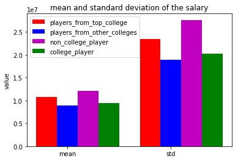

```python
ind = np.arange(2)
width = 0.20
fig , ax = plt.subplots()
rects1 = plt.bar(ind, salarydetails_of_players_from_topcollege, width, color = 'r', label='players_from_top_college')
rects2 = plt.bar(ind+ width, salarydetails_of_players_from_othercollege, width , color ='b',label = 'players_from_other_colleges')
rects3 = plt.bar(ind+ width*2,salarydetails_of_non_college_player , width , color ='m',label = 'non_college_player')
rects4 = plt.bar(ind+ width*3 , salarydetails_of_college_player , width , color='g',label = 'college_player')
plt.xticks(ind+ width ,('mean','std'))
ax.set_ylabel('value')
ax.set_title('mean and standard deviation of the salary')
ax.legend()
plt.show()
```

The players who haven't attend any college tops in the salary has higher mean than others. on other hand their standard deviation is also high . It denotes the variation in the salary among the group. Some players have a lucrative salary package while some players have a salary that is much less than others . It leads to the high standard deviation in that group.

Players from the top college has mean close to the player who haven't attend any college and their standard deviation is less comparable to them. Players from the top college get a decent mean for salary comparing to the mean of the players from the other college.

Meanwhile the players from the other college has a mean lower than the other groups and their standard deviation is low. Most of the players from this groups seems to get the average amount of the salary.

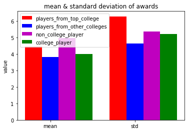

```python
ind = np.arange(2)
width = 0.20
fig , ax = plt.subplots()
rects1 = plt.bar(ind, awarddetails_of_players_from_topcollege, width, color = 'r', label='players_from_top_college')
rects2 = plt.bar(ind+ width, awarddetails_of_players_from_othercollege, width , color ='b',label = 'players_from_other_colleges')
rects3 = plt.bar(ind+ width*2,awarddetails_of_non_college_player , width , color ='m',label = 'non_college_player')
rects4 = plt.bar(ind+ width*3 , awarddetails_of_college_player, width , color='g',label = 'college_player')
plt.xticks(ind+ width ,('mean','std'))
ax.set_ylabel('value')
ax.set_title('mean & standard deviation of awards')
ax.legend()
plt.show()
```

Player who haven't attend any college get a hefty amount of the awards comparing to others and their standarad deviation is not so high. Where as the players who attended the top college has the good mean but their standard deviation is abnormally high. The group may contain player with zero awards and the player with plenty of awards for their name leading to the mean and the standard deviation for the group. So using this we can't conclude anything about the group. so instead of mean and standard deviation i am going to calculate the percentage of players who got the awards and see any interesting information i can get from that.

```python
def calculate_percentage(x):
    ''' To calculate the percentage of players who received awards
    It counts the total players in the group and the number of players who received the awards
    Divide the number of player with the awards by total count of players and multiply by 100'''
    total_count = x['playerID'].count()
    player_with_awards = x['awardID'].count()
    answer = float(player_with_awards* 100.0 / total_count)
    return answer
```

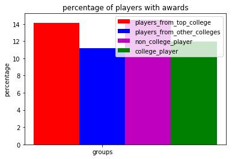

```python
awardpercentage_of_players_from_top_college = calculate_percentage(details_of_players_from_top_college)
awardpercentage_of_players_from_othercollege = calculate_percentage(details_of_players_from_other_college)
awardpercentage_of_non_college_player = calculate_percentage(details_of_non_college_player)
awardpercentage_of_college_player = calculate_percentage(details_of_college_player)
ind =  np.arange(1)
width = 0.2
fig , ax = plt.subplots()
rects1 = plt.bar(ind, awardpercentage_of_players_from_top_college, width, color = 'r', label='players_from_top_college')
rects2 = plt.bar(ind+ width, awardpercentage_of_players_from_othercollege, width , color ='b',label = 'players_from_other_colleges')
rects3 = plt.bar(ind+ width*2,awardpercentage_of_non_college_player , width , color ='m',label = 'non_college_player')
rects4 = plt.bar(ind+ width*3 , awardpercentage_of_college_player, width , color='g',label = 'college_player')
plt.xticks(ind + width ,('groups',))
ax.set_ylabel('percentage')
ax.set_title('percentage of players with awards')
plt.legend()
plt.show()
```

The percentage of players who got awards are nearly equal for players from top college and the players who haven't attend the college. chance of getting awards for the players from the other college is low comparing to other.

# Conclusion

By this analysis we can't conclude that players who haven't attended any colleges are being successful in the career. They may be getting high salary and awards due to lot of different factors so we can't compare the players who have attend the college to the players who haven't attend college.

But difference here between the players who from the top college and the players from the other college is cleary visible in every chart. They are splited based on the number of baseball players from each college . Those college who have 40 players as their alumini is grouped into top college and the remaining players are grouped into other college players. top college players has the high mean for the salary and the percentages of the awards gotten by the players also high comparing to the players from the other college. It doesn't mean you can't be successful when you study in the other colleges.But the probability is low comparing with the others.

# Reference

1. Baseball pay and performance https://ai.arizona.edu/sites/ai/files/MIS580/baseball.pdf
2. Baseball free agency and salary arbitration https://kb.osu.edu/dspace/bitstream/handle/1811/76189/1/OSJDR_V3N1_243.pdf